# Time Series: A First Course with Bootstrap Starter

# Lesson 2-2: Stochastic Processes

- A collection of random variables indexed by time is called a *stochastic process*, denoted as $\{ X_t \}$. The curly brackets let us know $\{ X_t \}$ is the process, whereas $X_t$ is a single random variable (at time $t$).
- Usually time is $t \in {\mathbf Z}$, the integers.
- There are also continuous-time stochastic processes (another subject).

## Realization is Sample Path

- A random variable $X_t$ has realization $x_t$.
- Example: $X_t \sim \mathcal{N}(0,1)$ has realization -0.5604756.
- Put this together for all $t \in {\mathbf Z}$, and the realization is called the *sample path*.

### Example: Heavy-tailed Sample Path

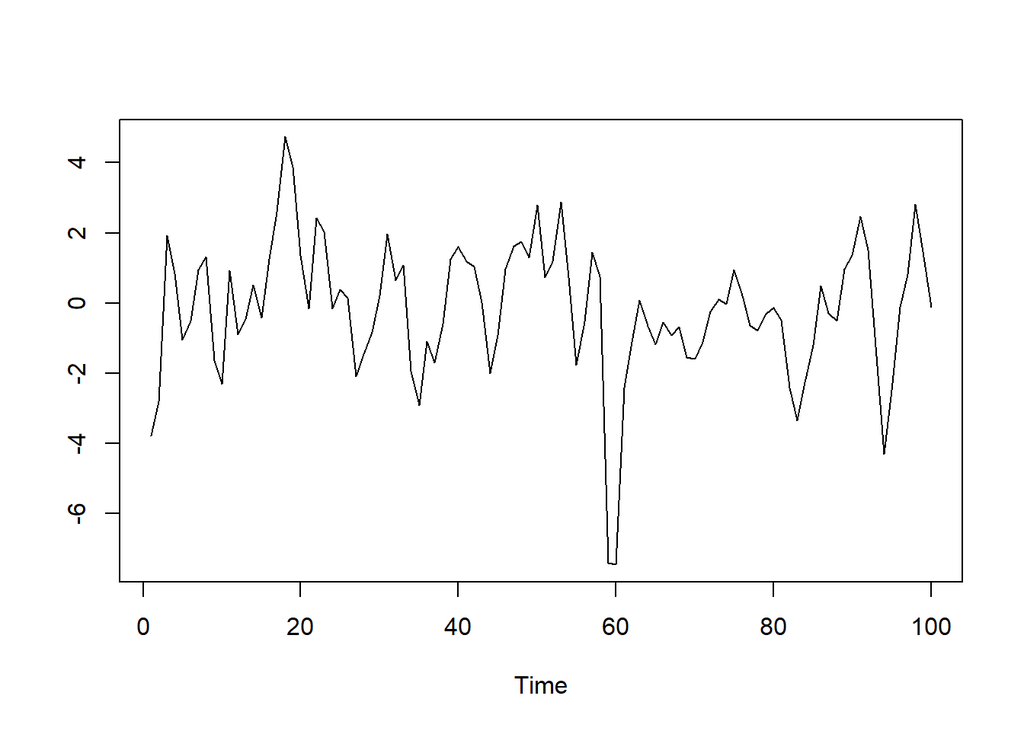

```r
set.seed(777)
n <- 100
z <- rt(n+1,df=4)       # heavy-tailed input
theta <- .8
x <- z[-1] + theta*z[-(n+1)]
plot(ts(x),xlab="Time",ylab="")
```

- As usual, we connect the dots when graphing the sample path.
- Here is another realization, or sample path, of the same stochastic process.

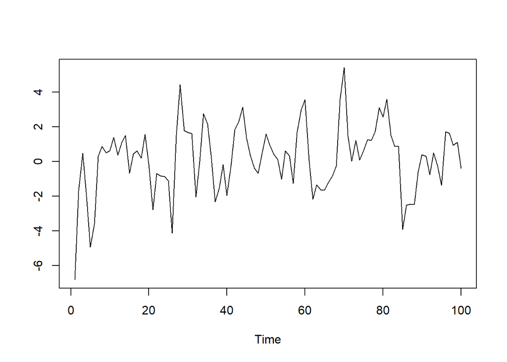

```r
set.seed(888)
n <- 100
z <- rt(n+1,df=4)       # heavy-tailed input
theta <- .8
x <- z[-1] + theta*z[-(n+1)]
plot(ts(x),xlab="Time",ylab="")
```

## Common Examples of Stochastic Processes

### Example 2.2.8. Process A: i.i.d.

- An i.i.d. process, where each $X_t$ has the same distribution and is independent of the rest.

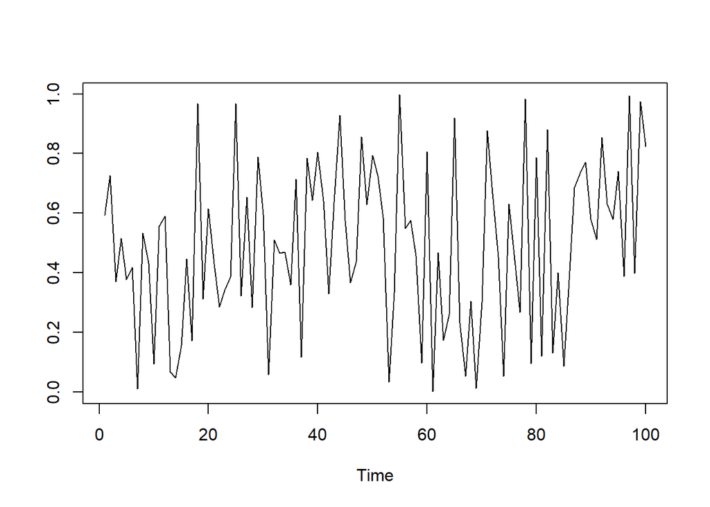

```r
set.seed(111)
n <- 100
x <- runif(n)
plot(ts(x),xlab="Time",ylab="")
```

### Example 2.2.9. Process B: Cosine

- Suppose $X_t = A \cos (\vartheta t + \Phi)$, where $\vartheta$ is given, and $A$ and $\Phi$ are independent random variables.

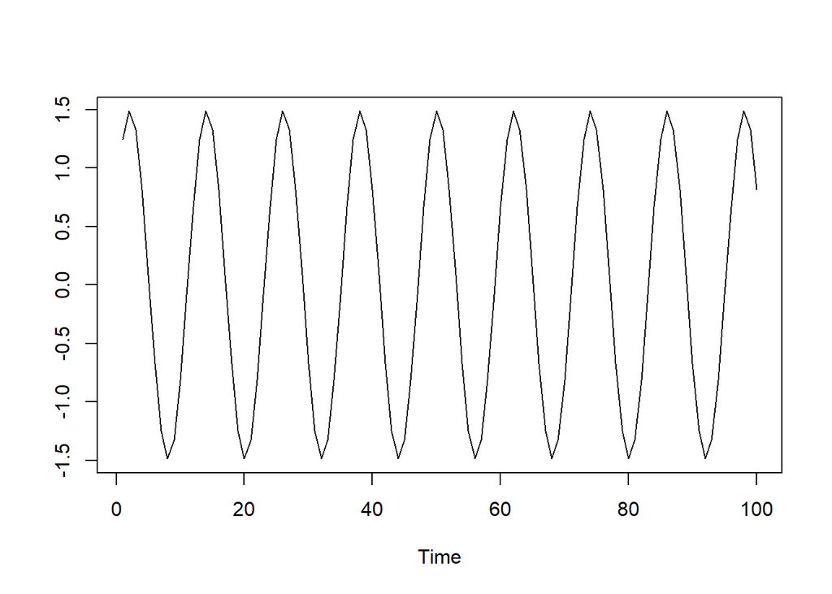

```r
n <- 100
set.seed(222)
A <- rnorm(1)
set.seed(223)
phi <- 2*pi*runif(1)
lambda <- pi/6
set.seed(224)
x <- A*cos(seq(1,n)*lambda + phi)
plot(ts(x),xlab="Time",ylab="")
```

### Example 2.2.12. Process E: Random Walk

- Suppose $X_t$ is current location on a straight line, and we step forward or backward at time $t+1$. Let the step size be given by random variable $Z_{t+1}$, independent of where we are. Then our new location is
  $$X_{t+1} = X_t + Z_{t+1}.$$
  This is called a *random walk*.
- We can initialize with $X_0 = 0$, for example.

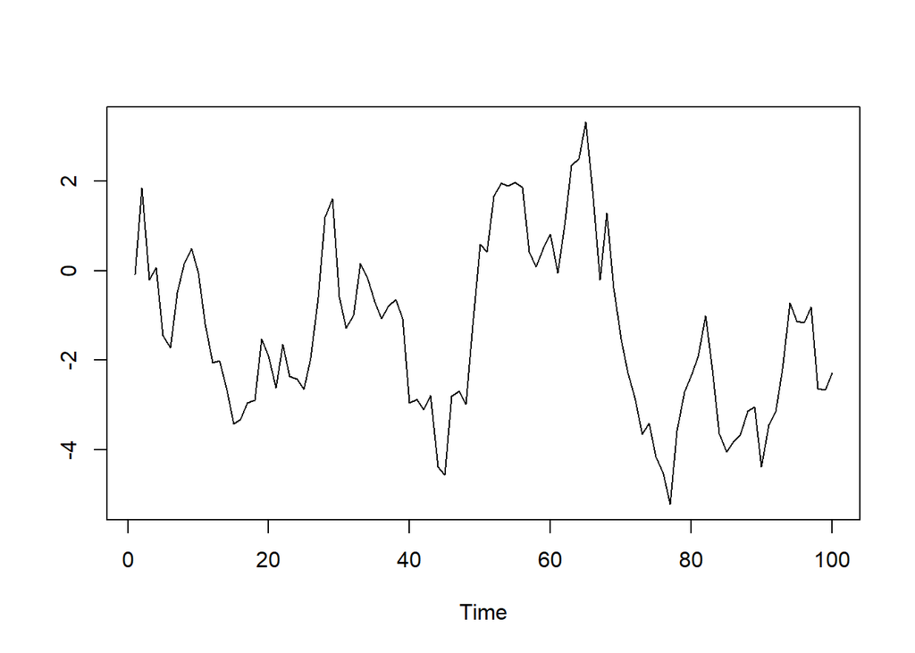

```r
set.seed(333)
n <- 100
z <- rnorm(n)
x <- rep(0,n)
x0 <- 0
x[1] <- x0 + z[1]
for(t in 2:n) { x[t] <- x[t-1] + z[t] }
plot(ts(x),xlab="Time",ylab="")
```